# Risk Factor Analysis

## Outcome Variable

**Outcome Variable:** ever_stunted

## Predictor Variables

**Intervention Variable:** mage

**Adjustment Set:**

unadjusted

## Stratifying Variables

The analysis was stratified on these variable(s):

- agecat
- studyid

The following strata were considered:

- agecat: 12 months, studyid: ki0047075b-MAL-ED
- agecat: 12 months, studyid: ki1000108-CMC-V-BCS-2002
- agecat: 12 months, studyid: ki1000108-IRC
- agecat: 12 months, studyid: ki1000109-EE
- agecat: 12 months, studyid: ki1000304b-SAS-FoodSuppl
- agecat: 12 months, studyid: ki1017093-NIH-Birth
- agecat: 12 months, studyid: ki1017093b-PROVIDE
- agecat: 12 months, studyid: ki1017093c-NIH-Crypto
- agecat: 12 months, studyid: ki1066203-TanzaniaChild2
- agecat: 12 months, studyid: ki1101329-Keneba
- agecat: 12 months, studyid: ki1112895-Guatemala BSC
- agecat: 12 months, studyid: ki1113344-GMS-Nepal
- agecat: 12 months, studyid: ki1126311-ZVITAMBO
- agecat: 12 months, studyid: ki1135781-COHORTS
- agecat: 12 months, studyid: ki1148112-LCNI-5
- agecat: 18 months, studyid: ki0047075b-MAL-ED
- agecat: 18 months, studyid: ki1000108-CMC-V-BCS-2002
- agecat: 18 months, studyid: ki1000108-IRC
- agecat: 18 months, studyid: ki1000109-EE
- agecat: 18 months, studyid: ki1000304b-SAS-FoodSuppl
- agecat: 18 months, studyid: ki1017093-NIH-Birth
- agecat: 18 months, studyid: ki1017093b-PROVIDE
- agecat: 18 months, studyid: ki1017093c-NIH-Crypto
- agecat: 18 months, studyid: ki1066203-TanzaniaChild2
- agecat: 18 months, studyid: ki1101329-Keneba
- agecat: 18 months, studyid: ki1112895-Guatemala BSC
- agecat: 18 months, studyid: ki1113344-GMS-Nepal
- agecat: 18 months, studyid: ki1126311-ZVITAMBO
- agecat: 18 months, studyid: ki1135781-COHORTS
- agecat: 18 months, studyid: ki1148112-LCNI-5
- agecat: 24 months, studyid: ki0047075b-MAL-ED
- agecat: 24 months, studyid: ki1000108-CMC-V-BCS-2002
- agecat: 24 months, studyid: ki1000108-IRC
- agecat: 24 months, studyid: ki1000109-EE
- agecat: 24 months, studyid: ki1000304b-SAS-FoodSuppl
- agecat: 24 months, studyid: ki1017093-NIH-Birth
- agecat: 24 months, studyid: ki1017093b-PROVIDE
- agecat: 24 months, studyid: ki1017093c-NIH-Crypto
- agecat: 24 months, studyid: ki1066203-TanzaniaChild2
- agecat: 24 months, studyid: ki1101329-Keneba
- agecat: 24 months, studyid: ki1113344-GMS-Nepal
- agecat: 24 months, studyid: ki1126311-ZVITAMBO
- agecat: 24 months, studyid: ki1135781-COHORTS
- agecat: 24 months, studyid: ki1148112-LCNI-5
- agecat: 3 months, studyid: ki0047075b-MAL-ED
- agecat: 3 months, studyid: ki1000108-CMC-V-BCS-2002
- agecat: 3 months, studyid: ki1000108-IRC
- agecat: 3 months, studyid: ki1000109-EE
- agecat: 3 months, studyid: ki1017093-NIH-Birth
- agecat: 3 months, studyid: ki1017093b-PROVIDE
- agecat: 3 months, studyid: ki1017093c-NIH-Crypto
- agecat: 3 months, studyid: ki1066203-TanzaniaChild2
- agecat: 3 months, studyid: ki1101329-Keneba
- agecat: 3 months, studyid: ki1113344-GMS-Nepal
- agecat: 3 months, studyid: ki1126311-ZVITAMBO
- agecat: 3 months, studyid: ki1135781-COHORTS
- agecat: 6 months, studyid: ki0047075b-MAL-ED
- agecat: 6 months, studyid: ki1000108-CMC-V-BCS-2002
- agecat: 6 months, studyid: ki1000108-IRC
- agecat: 6 months, studyid: ki1000109-EE
- agecat: 6 months, studyid: ki1000304b-SAS-FoodSuppl
- agecat: 6 months, studyid: ki1017093-NIH-Birth
- agecat: 6 months, studyid: ki1017093b-PROVIDE
- agecat: 6 months, studyid: ki1017093c-NIH-Crypto
- agecat: 6 months, studyid: ki1066203-TanzaniaChild2
- agecat: 6 months, studyid: ki1101329-Keneba
- agecat: 6 months, studyid: ki1112895-Guatemala BSC
- agecat: 6 months, studyid: ki1113344-GMS-Nepal
- agecat: 6 months, studyid: ki1126311-ZVITAMBO
- agecat: 6 months, studyid: ki1135781-COHORTS
- agecat: 6 months, studyid: ki1148112-LCNI-5

### Dropped Strata

Some strata were dropped due to rare outcomes:

- agecat: 3 months, studyid: ki1000109-EE
- agecat: 6 months, studyid: ki1000109-EE
- agecat: 6 months, studyid: ki1112895-Guatemala BSC
- agecat: 12 months, studyid: ki1000109-EE
- agecat: 12 months, studyid: ki1000304b-SAS-FoodSuppl
- agecat: 12 months, studyid: ki1112895-Guatemala BSC
- agecat: 18 months, studyid: ki1000109-EE
- agecat: 18 months, studyid: ki1000304b-SAS-FoodSuppl
- agecat: 18 months, studyid: ki1112895-Guatemala BSC
- agecat: 24 months, studyid: ki1000108-CMC-V-BCS-2002
- agecat: 24 months, studyid: ki1000109-EE
- agecat: 24 months, studyid: ki1000304b-SAS-FoodSuppl

## Methods Detail

We’re interested in the causal parameters $E[Y_a]$ for all values of $a \in \mathcal{A}$. These parameters represent the mean outcome if, possibly contrary to fact, we intervened to set all units to have $A=a$. Under the randomization and positivity assumptions, these are identified by the statistical parameters $\psi_a=E_W[E_{Y|A,W}(Y|A=a,W)]$. In addition, we’re interested in the mean of $Y$, $E[Y]$ under no intervention (the observed mean). We will estimate these parameters by using SuperLearner to fit the relevant likelihood factors – $E_{Y|A,W}(Y|A=a,W)$ and $p(A=a|W)$, and then updating our likelihood fit using a joint TMLE.

For unadjusted analyses ($W=\{\}$), initial likelihoods were estimated using Lrnr_glm to estimate the simple $E(Y|A)$ and Lrnr_mean to estimate $p(A)$. For adjusted analyses, a small library containing Lrnr_glmnet, Lrnr_xgboost, and Lrnr_mean was used.

Having estimated these parameters, we will then use the delta method to estimate relative risks and attributable risks relative to a prespecified baseline level of $A$.

# Results Detail

## Results Plots

[figure not shown]

[figure not shown]

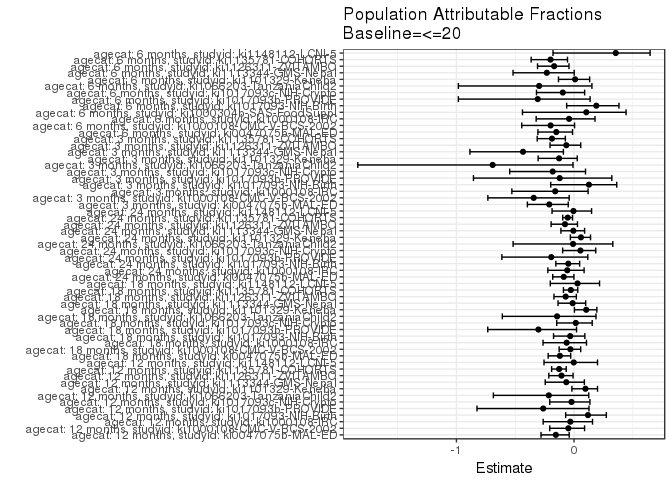

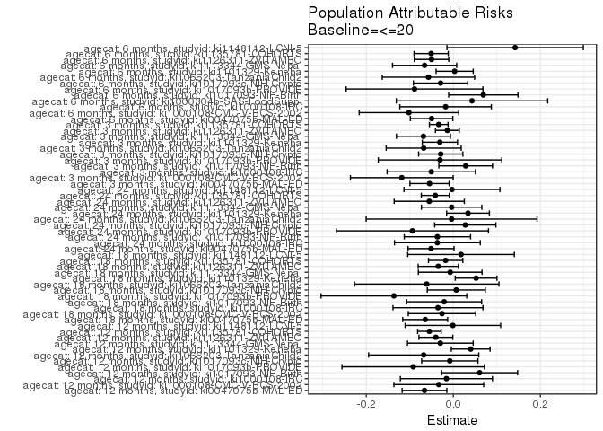

## Data Summary

| agecat | studyid | A | n | nA | nAY0 | nAY1 |
| --- | --- | --- | --- | --- | --- | --- |
| 3 months | ki0047075b-MAL-ED | <=20 | 1866 | 410 | 281 | 129 |
| 3 months | ki0047075b-MAL-ED | (20-24] | 1866 | 453 | 335 | 118 |
| 3 months | ki0047075b-MAL-ED | (24-28] | 1866 | 497 | 378 | 119 |
| 3 months | ki0047075b-MAL-ED | >28 | 1866 | 506 | 387 | 119 |
| 3 months | ki1000108-CMC-V-BCS-2002 | <=20 | 362 | 69 | 37 | 32 |
| 3 months | ki1000108-CMC-V-BCS-2002 | (20-24] | 362 | 146 | 100 | 46 |
| 3 months | ki1000108-CMC-V-BCS-2002 | (24-28] | 362 | 97 | 63 | 34 |
| 3 months | ki1000108-CMC-V-BCS-2002 | >28 | 362 | 50 | 37 | 13 |
| 3 months | ki1000108-IRC | <=20 | 410 | 87 | 55 | 32 |
| 3 months | ki1000108-IRC | (20-24] | 410 | 171 | 119 | 52 |
| 3 months | ki1000108-IRC | (24-28] | 410 | 108 | 74 | 34 |
| 3 months | ki1000108-IRC | >28 | 410 | 44 | 32 | 12 |
| 3 months | ki1000109-EE | <=20 | 377 | 4 | 1 | 3 |
| 3 months | ki1000109-EE | (20-24] | 377 | 18 | 5 | 13 |
| 3 months | ki1000109-EE | (24-28] | 377 | 115 | 34 | 81 |
| 3 months | ki1000109-EE | >28 | 377 | 240 | 97 | 143 |
| 3 months | ki1000304b-SAS-FoodSuppl | <=20 | 0 | 0 | 0 | 0 |
| 3 months | ki1000304b-SAS-FoodSuppl | (20-24] | 0 | 0 | 0 | 0 |
| 3 months | ki1000304b-SAS-FoodSuppl | (24-28] | 0 | 0 | 0 | 0 |
| 3 months | ki1000304b-SAS-FoodSuppl | >28 | 0 | 0 | 0 | 0 |
| 3 months | ki1017093-NIH-Birth | <=20 | 627 | 159 | 128 | 31 |
| 3 months | ki1017093-NIH-Birth | (20-24] | 627 | 154 | 117 | 37 |
| 3 months | ki1017093-NIH-Birth | (24-28] | 627 | 170 | 129 | 41 |
| 3 months | ki1017093-NIH-Birth | >28 | 627 | 144 | 113 | 31 |
| 3 months | ki1017093b-PROVIDE | <=20 | 175 | 39 | 28 | 11 |
| 3 months | ki1017093b-PROVIDE | (20-24] | 175 | 56 | 42 | 14 |
| 3 months | ki1017093b-PROVIDE | (24-28] | 175 | 46 | 38 | 8 |
| 3 months | ki1017093b-PROVIDE | >28 | 175 | 34 | 23 | 11 |
| 3 months | ki1017093c-NIH-Crypto | <=20 | 758 | 228 | 185 | 43 |
| 3 months | ki1017093c-NIH-Crypto | (20-24] | 758 | 171 | 141 | 30 |

[output cut: 270 more lines]

## Results Table

### Parameter: TSM

| agecat | studyid | intervention_level | baseline_level | estimate | ci_lower | ci_upper |
| --- | --- | --- | --- | --- | --- | --- |
| 3 months | ki0047075b-MAL-ED | <=20 | NA | 0.3146341 | 0.2696731 | 0.3595952 |
| 3 months | ki0047075b-MAL-ED | (20-24] | NA | 0.2604857 | 0.2200578 | 0.3009135 |
| 3 months | ki0047075b-MAL-ED | (24-28] | NA | 0.2394366 | 0.2019091 | 0.2769641 |
| 3 months | ki0047075b-MAL-ED | >28 | NA | 0.2351779 | 0.1982148 | 0.2721409 |
| 3 months | ki1000108-CMC-V-BCS-2002 | <=20 | NA | 0.4637681 | 0.3459394 | 0.5815968 |
| 3 months | ki1000108-CMC-V-BCS-2002 | (20-24] | NA | 0.3150685 | 0.2396117 | 0.3905253 |
| 3 months | ki1000108-CMC-V-BCS-2002 | (24-28] | NA | 0.3505155 | 0.2554329 | 0.4455980 |
| 3 months | ki1000108-CMC-V-BCS-2002 | >28 | NA | 0.2600000 | 0.1382507 | 0.3817493 |
| 3 months | ki1000108-IRC | <=20 | NA | 0.3678161 | 0.2663652 | 0.4692670 |
| 3 months | ki1000108-IRC | (20-24] | NA | 0.3040936 | 0.2350602 | 0.3731270 |
| 3 months | ki1000108-IRC | (24-28] | NA | 0.3148148 | 0.2271151 | 0.4025145 |
| 3 months | ki1000108-IRC | >28 | NA | 0.2727273 | 0.1409729 | 0.4044816 |
| 3 months | ki1017093-NIH-Birth | <=20 | NA | 0.1949686 | 0.1333396 | 0.2565975 |
| 3 months | ki1017093-NIH-Birth | (20-24] | NA | 0.2402597 | 0.1727281 | 0.3077914 |
| 3 months | ki1017093-NIH-Birth | (24-28] | NA | 0.2411765 | 0.1768176 | 0.3055353 |
| 3 months | ki1017093-NIH-Birth | >28 | NA | 0.2152778 | 0.1480930 | 0.2824626 |
| 3 months | ki1017093b-PROVIDE | <=20 | NA | 0.2820513 | 0.1404162 | 0.4236864 |
| 3 months | ki1017093b-PROVIDE | (20-24] | NA | 0.2500000 | 0.1362637 | 0.3637363 |
| 3 months | ki1017093b-PROVIDE | (24-28] | NA | 0.1739130 | 0.0640649 | 0.2837611 |
| 3 months | ki1017093b-PROVIDE | >28 | NA | 0.3235294 | 0.1658284 | 0.4812304 |
| 3 months | ki1017093c-NIH-Crypto | <=20 | NA | 0.1885965 | 0.1377861 | 0.2394069 |
| 3 months | ki1017093c-NIH-Crypto | (20-24] | NA | 0.1754386 | 0.1183945 | 0.2324827 |
| 3 months | ki1017093c-NIH-Crypto | (24-28] | NA | 0.1374408 | 0.0909522 | 0.1839293 |
| 3 months | ki1017093c-NIH-Crypto | >28 | NA | 0.1283784 | 0.0744504 | 0.1823063 |
| 3 months | ki1066203-TanzaniaChild2 | <=20 | NA | 0.1666667 | 0.0805121 | 0.2528213 |
| 3 months | ki1066203-TanzaniaChild2 | (20-24] | NA | 0.1069182 | 0.0588472 | 0.1549893 |
| 3 months | ki1066203-TanzaniaChild2 | (24-28] | NA | 0.0935673 | 0.0498812 | 0.1372533 |
| 3 months | ki1066203-TanzaniaChild2 | >28 | NA | 0.0710660 | 0.0351572 | 0.1069748 |
| 3 months | ki1101329-Keneba | <=20 | NA | 0.2750533 | 0.2346313 | 0.3154754 |
| 3 months | ki1101329-Keneba | (20-24] | NA | 0.2385120 | 0.1994305 | 0.2775936 |

[output cut: 206 more lines]

### Parameter: E(Y)

| agecat | studyid | intervention_level | baseline_level | estimate | ci_lower | ci_upper |
| --- | --- | --- | --- | --- | --- | --- |
| 3 months | ki0047075b-MAL-ED | NA | NA | 0.2599143 | 0.2585261 | 0.2613025 |
| 3 months | ki1000108-CMC-V-BCS-2002 | NA | NA | 0.3453039 | 0.3387342 | 0.3518735 |
| 3 months | ki1000108-IRC | NA | NA | 0.3170732 | 0.3142828 | 0.3198636 |
| 3 months | ki1017093-NIH-Birth | NA | NA | 0.2232855 | 0.2217673 | 0.2248037 |
| 3 months | ki1017093b-PROVIDE | NA | NA | 0.2514286 | 0.2435675 | 0.2592896 |
| 3 months | ki1017093c-NIH-Crypto | NA | NA | 0.1596306 | 0.1578334 | 0.1614278 |
| 3 months | ki1066203-TanzaniaChild2 | NA | NA | 0.0984975 | 0.0961859 | 0.1008091 |
| 3 months | ki1101329-Keneba | NA | NA | 0.2440841 | 0.2434057 | 0.2447626 |
| 3 months | ki1113344-GMS-Nepal | NA | NA | 0.1585160 | 0.1544939 | 0.1625381 |
| 3 months | ki1126311-ZVITAMBO | NA | NA | 0.2101947 | 0.2094908 | 0.2108986 |
| 3 months | ki1135781-COHORTS | NA | NA | 0.1792074 | 0.1788334 | 0.1795813 |
| 6 months | ki0047075b-MAL-ED | NA | NA | 0.3321879 | 0.3307016 | 0.3336742 |
| 6 months | ki1000108-CMC-V-BCS-2002 | NA | NA | 0.5122616 | 0.5063824 | 0.5181407 |
| 6 months | ki1000108-IRC | NA | NA | 0.4240196 | 0.4210268 | 0.4270124 |
| 6 months | ki1000304b-SAS-FoodSuppl | NA | NA | 0.4095238 | 0.3938003 | 0.4252473 |
| 6 months | ki1017093-NIH-Birth | NA | NA | 0.3624772 | 0.3591084 | 0.3658461 |
| 6 months | ki1017093b-PROVIDE | NA | NA | 0.2891566 | 0.2780788 | 0.3002345 |
| 6 months | ki1017093c-NIH-Crypto | NA | NA | 0.3070652 | 0.3051647 | 0.3089657 |
| 6 months | ki1066203-TanzaniaChild2 | NA | NA | 0.1927928 | 0.1896697 | 0.1959159 |
| 6 months | ki1101329-Keneba | NA | NA | 0.3232413 | 0.3227868 | 0.3236959 |
| 6 months | ki1113344-GMS-Nepal | NA | NA | 0.2857143 | 0.2819933 | 0.2894353 |
| 6 months | ki1126311-ZVITAMBO | NA | NA | 0.2969298 | 0.2955177 | 0.2983419 |
| 6 months | ki1135781-COHORTS | NA | NA | 0.2551748 | 0.2538444 | 0.2565051 |
| 6 months | ki1148112-LCNI-5 | NA | NA | 0.4000000 | 0.3754308 | 0.4245692 |
| 12 months | ki0047075b-MAL-ED | NA | NA | 0.4295024 | 0.4276454 | 0.4313594 |
| 12 months | ki1000108-CMC-V-BCS-2002 | NA | NA | 0.6989247 | 0.6967026 | 0.7011469 |
| 12 months | ki1000108-IRC | NA | NA | 0.5073529 | 0.5030392 | 0.5116667 |
| 12 months | ki1017093-NIH-Birth | NA | NA | 0.5083488 | 0.5047265 | 0.5119711 |
| 12 months | ki1017093b-PROVIDE | NA | NA | 0.3522013 | 0.3366281 | 0.3677744 |
| 12 months | ki1017093c-NIH-Crypto | NA | NA | 0.3799726 | 0.3777311 | 0.3822140 |
| 12 months | ki1066203-TanzaniaChild2 | NA | NA | 0.3178138 | 0.3144558 | 0.3211717 |
| 12 months | ki1101329-Keneba | NA | NA | 0.4093220 | 0.4081136 | 0.4105305 |
| 12 months | ki1113344-GMS-Nepal | NA | NA | 0.4553265 | 0.4526130 | 0.4580399 |
| 12 months | ki1126311-ZVITAMBO | NA | NA | 0.3775591 | 0.3764558 | 0.3786623 |
| 12 months | ki1135781-COHORTS | NA | NA | 0.4347091 | 0.4339218 | 0.4354965 |
| 12 months | ki1148112-LCNI-5 | NA | NA | 0.4864048 | 0.4844181 | 0.4883916 |
| 18 months | ki0047075b-MAL-ED | NA | NA | 0.5393676 | 0.5375572 | 0.5411781 |
| 18 months | ki1000108-CMC-V-BCS-2002 | NA | NA | 0.8471850 | 0.8454665 | 0.8489035 |
| 18 months | ki1000108-IRC | NA | NA | 0.5623472 | 0.5563655 | 0.5683289 |
| 18 months | ki1017093-NIH-Birth | NA | NA | 0.6484848 | 0.6471509 | 0.6498188 |
| 18 months | ki1017093b-PROVIDE | NA | NA | 0.4516129 | 0.4303022 | 0.4729236 |
| 18 months | ki1017093c-NIH-Crypto | NA | NA | 0.4433566 | 0.4426357 | 0.4440776 |
| 18 months | ki1066203-TanzaniaChild2 | NA | NA | 0.4245810 | 0.4200220 | 0.4291400 |
| 18 months | ki1101329-Keneba | NA | NA | 0.5028723 | 0.5013214 | 0.5044232 |
| 18 months | ki1113344-GMS-Nepal | NA | NA | 0.6236934 | 0.6211614 | 0.6262254 |
| 18 months | ki1126311-ZVITAMBO | NA | NA | 0.4865156 | 0.4854492 | 0.4875821 |
| 18 months | ki1135781-COHORTS | NA | NA | 0.6477457 | 0.6468359 | 0.6486555 |
| 18 months | ki1148112-LCNI-5 | NA | NA | 0.5890909 | 0.5860905 | 0.5920913 |
| 24 months | ki0047075b-MAL-ED | NA | NA | 0.5871261 | 0.5855151 | 0.5887372 |
| 24 months | ki1000108-IRC | NA | NA | 0.6414634 | 0.6348619 | 0.6480650 |
| 24 months | ki1017093-NIH-Birth | NA | NA | 0.7542735 | 0.7505159 | 0.7580311 |
| 24 months | ki1017093b-PROVIDE | NA | NA | 0.4864865 | 0.4722638 | 0.5007092 |
| 24 months | ki1017093c-NIH-Crypto | NA | NA | 0.5015773 | 0.4998954 | 0.5032592 |
| 24 months | ki1066203-TanzaniaChild2 | NA | NA | 0.4760000 | 0.4699409 | 0.4820591 |
| 24 months | ki1101329-Keneba | NA | NA | 0.5741080 | 0.5729757 | 0.5752402 |
| 24 months | ki1113344-GMS-Nepal | NA | NA | 0.6901408 | 0.6866976 | 0.6935841 |
| 24 months | ki1126311-ZVITAMBO | NA | NA | 0.7212766 | 0.7179654 | 0.7245878 |
| 24 months | ki1135781-COHORTS | NA | NA | 0.7750329 | 0.7741206 | 0.7759453 |
| 24 months | ki1148112-LCNI-5 | NA | NA | 0.6587838 | 0.6561788 | 0.6613888 |

### Parameter: RR

| agecat | studyid | intervention_level | baseline_level | estimate | ci_lower | ci_upper |
| --- | --- | --- | --- | --- | --- | --- |
| 3 months | ki0047075b-MAL-ED | (20-24] | <=20 | 0.8279001 | 0.6704329 | 1.0223523 |
| 3 months | ki0047075b-MAL-ED | (24-28] | <=20 | 0.7610001 | 0.6155622 | 0.9408003 |
| 3 months | ki0047075b-MAL-ED | >28 | <=20 | 0.7474645 | 0.6044176 | 0.9243662 |
| 3 months | ki1000108-CMC-V-BCS-2002 | (20-24] | <=20 | 0.6793664 | 0.4791472 | 0.9632504 |
| 3 months | ki1000108-CMC-V-BCS-2002 | (24-28] | <=20 | 0.7557990 | 0.5211875 | 1.0960203 |
| 3 months | ki1000108-CMC-V-BCS-2002 | >28 | <=20 | 0.5606250 | 0.3290800 | 0.9550881 |
| 3 months | ki1000108-IRC | (20-24] | <=20 | 0.8267544 | 0.5784082 | 1.1817308 |
| 3 months | ki1000108-IRC | (24-28] | <=20 | 0.8559028 | 0.5783247 | 1.2667098 |
| 3 months | ki1000108-IRC | >28 | <=20 | 0.7414773 | 0.4251117 | 1.2932802 |
| 3 months | ki1017093-NIH-Birth | (20-24] | <=20 | 1.2323000 | 0.8072601 | 1.8811325 |
| 3 months | ki1017093-NIH-Birth | (24-28] | <=20 | 1.2370019 | 0.8179241 | 1.8708016 |
| 3 months | ki1017093-NIH-Birth | >28 | <=20 | 1.1041667 | 0.7081429 | 1.7216637 |
| 3 months | ki1017093b-PROVIDE | (20-24] | <=20 | 0.8863636 | 0.4501262 | 1.7453781 |
| 3 months | ki1017093b-PROVIDE | (24-28] | <=20 | 0.6166008 | 0.2751464 | 1.3817974 |
| 3 months | ki1017093b-PROVIDE | >28 | <=20 | 1.1470588 | 0.5697091 | 2.3095012 |
| 3 months | ki1017093c-NIH-Crypto | (20-24] | <=20 | 0.9302326 | 0.6098241 | 1.4189872 |
| 3 months | ki1017093c-NIH-Crypto | (24-28] | <=20 | 0.7287556 | 0.4729133 | 1.1230066 |
| 3 months | ki1017093c-NIH-Crypto | >28 | <=20 | 0.6807040 | 0.4132637 | 1.1212160 |
| 3 months | ki1066203-TanzaniaChild2 | (20-24] | <=20 | 0.6415094 | 0.3233469 | 1.2727334 |
| 3 months | ki1066203-TanzaniaChild2 | (24-28] | <=20 | 0.5614035 | 0.2797437 | 1.1266525 |
| 3 months | ki1066203-TanzaniaChild2 | >28 | <=20 | 0.4263959 | 0.2069559 | 0.8785133 |
| 3 months | ki1101329-Keneba | (20-24] | <=20 | 0.8671484 | 0.6958299 | 1.0806468 |
| 3 months | ki1101329-Keneba | (24-28] | <=20 | 0.8907364 | 0.7103534 | 1.1169249 |
| 3 months | ki1101329-Keneba | >28 | <=20 | 0.8404609 | 0.6971183 | 1.0132778 |
| 3 months | ki1113344-GMS-Nepal | (20-24] | <=20 | 0.6453333 | 0.4021861 | 1.0354786 |
| 3 months | ki1113344-GMS-Nepal | (24-28] | <=20 | 0.4266667 | 0.2486597 | 0.7321027 |
| 3 months | ki1113344-GMS-Nepal | >28 | <=20 | 0.6901961 | 0.4077141 | 1.1683939 |
| 3 months | ki1126311-ZVITAMBO | (20-24] | <=20 | 0.9965475 | 0.8466561 | 1.1729756 |
| 3 months | ki1126311-ZVITAMBO | (24-28] | <=20 | 0.9480079 | 0.7892462 | 1.1387054 |
| 3 months | ki1126311-ZVITAMBO | >28 | <=20 | 0.7517271 | 0.6117473 | 0.9237372 |

[output cut: 147 more lines]

### Parameter: PAR

| agecat | studyid | intervention_level | baseline_level | estimate | ci_lower | ci_upper |
| --- | --- | --- | --- | --- | --- | --- |
| 3 months | ki0047075b-MAL-ED | <=20 | NA | -0.0547199 | -0.0997024 | -0.0097374 |
| 3 months | ki1000108-CMC-V-BCS-2002 | <=20 | NA | -0.1184642 | -0.2364759 | -0.0004526 |
| 3 months | ki1000108-IRC | <=20 | NA | -0.0507429 | -0.1522322 | 0.0507463 |
| 3 months | ki1017093-NIH-Birth | <=20 | NA | 0.0283169 | -0.0333307 | 0.0899646 |
| 3 months | ki1017093b-PROVIDE | <=20 | NA | -0.0306227 | -0.1724758 | 0.1112304 |
| 3 months | ki1017093c-NIH-Crypto | <=20 | NA | -0.0289659 | -0.0798081 | 0.0218763 |
| 3 months | ki1066203-TanzaniaChild2 | <=20 | NA | -0.0681692 | -0.1543548 | 0.0180164 |
| 3 months | ki1101329-Keneba | <=20 | NA | -0.0309692 | -0.0713969 | 0.0094586 |
| 3 months | ki1113344-GMS-Nepal | <=20 | NA | -0.0687567 | -0.1308519 | -0.0066615 |
| 3 months | ki1126311-ZVITAMBO | <=20 | NA | -0.0137694 | -0.0411258 | 0.0135869 |
| 3 months | ki1135781-COHORTS | <=20 | NA | -0.0336040 | -0.0550102 | -0.0121979 |
| 6 months | ki0047075b-MAL-ED | <=20 | NA | -0.0500111 | -0.0987765 | -0.0012457 |
| 6 months | ki1000108-CMC-V-BCS-2002 | <=20 | NA | -0.1020241 | -0.2163605 | 0.0123123 |
| 6 months | ki1000108-IRC | <=20 | NA | -0.0178409 | -0.1229697 | 0.0872880 |
| 6 months | ki1000304b-SAS-FoodSuppl | <=20 | NA | 0.0428571 | -0.1311224 | 0.2168367 |
| 6 months | ki1017093-NIH-Birth | <=20 | NA | 0.0688264 | -0.0108395 | 0.1484924 |
| 6 months | ki1017093b-PROVIDE | <=20 | NA | -0.0892218 | -0.2463548 | 0.0679113 |
| 6 months | ki1017093c-NIH-Crypto | <=20 | NA | -0.0292984 | -0.0918016 | 0.0332048 |
| 6 months | ki1066203-TanzaniaChild2 | <=20 | NA | -0.0572072 | -0.1634350 | 0.0490206 |
| 6 months | ki1101329-Keneba | <=20 | NA | 0.0029799 | -0.0397160 | 0.0456758 |
| 6 months | ki1113344-GMS-Nepal | <=20 | NA | -0.0661376 | -0.1398338 | 0.0075587 |
| 6 months | ki1126311-ZVITAMBO | <=20 | NA | -0.0501925 | -0.0897965 | -0.0105884 |
| 6 months | ki1135781-COHORTS | <=20 | NA | -0.0510634 | -0.0903711 | -0.0117557 |
| 6 months | ki1148112-LCNI-5 | <=20 | NA | 0.1419355 | -0.0147411 | 0.2986121 |
| 12 months | ki0047075b-MAL-ED | <=20 | NA | -0.0663880 | -0.1177297 | -0.0150464 |
| 12 months | ki1000108-CMC-V-BCS-2002 | <=20 | NA | -0.0334696 | -0.1366090 | 0.0696697 |
| 12 months | ki1000108-IRC | <=20 | NA | -0.0159029 | -0.1216803 | 0.0898745 |
| 12 months | ki1017093-NIH-Birth | <=20 | NA | 0.0603488 | -0.0269843 | 0.1476819 |
| 12 months | ki1017093b-PROVIDE | <=20 | NA | -0.0922432 | -0.2558180 | 0.0713317 |
| 12 months | ki1017093c-NIH-Crypto | <=20 | NA | -0.0081553 | -0.0727807 | 0.0564701 |
| 12 months | ki1066203-TanzaniaChild2 | <=20 | NA | -0.0681511 | -0.1947046 | 0.0584023 |
| 12 months | ki1101329-Keneba | <=20 | NA | 0.0398530 | -0.0046688 | 0.0843749 |
| 12 months | ki1113344-GMS-Nepal | <=20 | NA | -0.0298806 | -0.1053445 | 0.0455832 |
| 12 months | ki1126311-ZVITAMBO | <=20 | NA | -0.0401829 | -0.0790270 | -0.0013388 |
| 12 months | ki1135781-COHORTS | <=20 | NA | -0.0550713 | -0.0820417 | -0.0281009 |
| 12 months | ki1148112-LCNI-5 | <=20 | NA | -0.0010952 | -0.1108101 | 0.1086197 |
| 18 months | ki0047075b-MAL-ED | <=20 | NA | -0.0646786 | -0.1162572 | -0.0131000 |
| 18 months | ki1000108-CMC-V-BCS-2002 | <=20 | NA | -0.0260545 | -0.1035662 | 0.0514573 |
| 18 months | ki1000108-IRC | <=20 | NA | -0.0353540 | -0.1386932 | 0.0679853 |
| 18 months | ki1017093-NIH-Birth | <=20 | NA | -0.0210804 | -0.1071460 | 0.0649853 |
| 18 months | ki1017093b-PROVIDE | <=20 | NA | -0.1366224 | -0.3039491 | 0.0307043 |
| 18 months | ki1017093c-NIH-Crypto | <=20 | NA | 0.0067369 | -0.0599192 | 0.0733931 |
| 18 months | ki1066203-TanzaniaChild2 | <=20 | NA | -0.0611333 | -0.2270072 | 0.1047407 |
| 18 months | ki1101329-Keneba | <=20 | NA | 0.0522699 | 0.0043641 | 0.1001757 |
| 18 months | ki1113344-GMS-Nepal | <=20 | NA | -0.0072590 | -0.0803346 | 0.0658166 |
| 18 months | ki1126311-ZVITAMBO | <=20 | NA | -0.0346425 | -0.0808740 | 0.0115891 |
| 18 months | ki1135781-COHORTS | <=20 | NA | -0.0177088 | -0.0571582 | 0.0217405 |
| 18 months | ki1148112-LCNI-5 | <=20 | NA | 0.0176623 | -0.1047970 | 0.1401217 |
| 24 months | ki0047075b-MAL-ED | <=20 | NA | -0.0512386 | -0.1040889 | 0.0016117 |
| 24 months | ki1000108-IRC | <=20 | NA | -0.0366975 | -0.1352079 | 0.0618128 |
| 24 months | ki1017093-NIH-Birth | <=20 | NA | -0.0366356 | -0.1128042 | 0.0395331 |
| 24 months | ki1017093b-PROVIDE | <=20 | NA | -0.0941587 | -0.2690333 | 0.0807160 |
| 24 months | ki1017093c-NIH-Crypto | <=20 | NA | 0.0273505 | -0.0429902 | 0.0976911 |
| 24 months | ki1066203-TanzaniaChild2 | <=20 | NA | -0.0040000 | -0.2003259 | 0.1923259 |
| 24 months | ki1101329-Keneba | <=20 | NA | 0.0337039 | -0.0154053 | 0.0828131 |
| 24 months | ki1113344-GMS-Nepal | <=20 | NA | -0.0039768 | -0.0733889 | 0.0654353 |
| 24 months | ki1126311-ZVITAMBO | <=20 | NA | -0.0554224 | -0.1360031 | 0.0251582 |
| 24 months | ki1135781-COHORTS | <=20 | NA | -0.0415138 | -0.0737030 | -0.0093246 |
| 24 months | ki1148112-LCNI-5 | <=20 | NA | -0.0031880 | -0.1134362 | 0.1070601 |

### Parameter: PAF

| agecat | studyid | intervention_level | baseline_level | estimate | ci_lower | ci_upper |
| --- | --- | --- | --- | --- | --- | --- |
| 3 months | ki0047075b-MAL-ED | <=20 | NA | -0.2105306 | -0.3966242 | -0.0492330 |
| 3 months | ki1000108-CMC-V-BCS-2002 | <=20 | NA | -0.3430725 | -0.7328013 | -0.0409986 |
| 3 months | ki1000108-IRC | <=20 | NA | -0.1600354 | -0.5286889 | 0.1197149 |
| 3 months | ki1017093-NIH-Birth | <=20 | NA | 0.1268194 | -0.1978846 | 0.3635077 |
| 3 months | ki1017093b-PROVIDE | <=20 | NA | -0.1217949 | -0.8553312 | 0.3217255 |
| 3 months | ki1017093c-NIH-Crypto | <=20 | NA | -0.1814557 | -0.5471209 | 0.0977838 |
| 3 months | ki1066203-TanzaniaChild2 | <=20 | NA | -0.6920904 | -1.8389228 | -0.0085410 |
| 3 months | ki1101329-Keneba | <=20 | NA | -0.1268791 | -0.3053080 | 0.0271595 |
| 3 months | ki1113344-GMS-Nepal | <=20 | NA | -0.4337524 | -0.8853591 | -0.0903206 |
| 3 months | ki1126311-ZVITAMBO | <=20 | NA | -0.0655080 | -0.2039446 | 0.0570104 |
| 3 months | ki1135781-COHORTS | <=20 | NA | -0.1875148 | -0.3131861 | -0.0738702 |
| 6 months | ki0047075b-MAL-ED | <=20 | NA | -0.1505506 | -0.3071530 | -0.0127099 |
| 6 months | ki1000108-CMC-V-BCS-2002 | <=20 | NA | -0.1991641 | -0.4446420 | 0.0046014 |
| 6 months | ki1000108-IRC | <=20 | NA | -0.0420755 | -0.3220001 | 0.1785769 |
| 6 months | ki1000304b-SAS-FoodSuppl | <=20 | NA | 0.1046512 | -0.4384459 | 0.4426975 |
| 6 months | ki1017093-NIH-Birth | <=20 | NA | 0.1898780 | -0.0625175 | 0.3823182 |
| 6 months | ki1017093b-PROVIDE | <=20 | NA | -0.3085586 | -0.9836544 | 0.1367824 |
| 6 months | ki1017093c-NIH-Crypto | <=20 | NA | -0.0954143 | -0.3191271 | 0.0903587 |
| 6 months | ki1066203-TanzaniaChild2 | <=20 | NA | -0.2967290 | -0.9835361 | 0.1522685 |
| 6 months | ki1101329-Keneba | <=20 | NA | 0.0092187 | -0.1320772 | 0.1328794 |
| 6 months | ki1113344-GMS-Nepal | <=20 | NA | -0.2314815 | -0.5186294 | 0.0013715 |
| 6 months | ki1126311-ZVITAMBO | <=20 | NA | -0.1690382 | -0.3103580 | -0.0429595 |
| 6 months | ki1135781-COHORTS | <=20 | NA | -0.2001116 | -0.3645212 | -0.0555116 |
| 6 months | ki1148112-LCNI-5 | <=20 | NA | 0.3548387 | -0.1787958 | 0.6468998 |
| 12 months | ki0047075b-MAL-ED | <=20 | NA | -0.1545697 | -0.2805434 | -0.0409886 |
| 12 months | ki1000108-CMC-V-BCS-2002 | <=20 | NA | -0.0478873 | -0.2063559 | 0.0897646 |
| 12 months | ki1000108-IRC | <=20 | NA | -0.0313448 | -0.2624151 | 0.1574308 |
| 12 months | ki1017093-NIH-Birth | <=20 | NA | 0.1187153 | -0.0709305 | 0.2747777 |
| 12 months | ki1017093b-PROVIDE | <=20 | NA | -0.2619048 | -0.8251323 | 0.1275133 |
| 12 months | ki1017093c-NIH-Crypto | <=20 | NA | -0.0214628 | -0.2065265 | 0.1352147 |
| 12 months | ki1066203-TanzaniaChild2 | <=20 | NA | -0.2144374 | -0.6857731 | 0.1251147 |
| 12 months | ki1101329-Keneba | <=20 | NA | 0.0973635 | -0.0182228 | 0.1998286 |
| 12 months | ki1113344-GMS-Nepal | <=20 | NA | -0.0656247 | -0.2449607 | 0.0878781 |
| 12 months | ki1126311-ZVITAMBO | <=20 | NA | -0.1064281 | -0.2142555 | -0.0081759 |
| 12 months | ki1135781-COHORTS | <=20 | NA | -0.1266854 | -0.1904754 | -0.0663136 |
| 12 months | ki1148112-LCNI-5 | <=20 | NA | -0.0022516 | -0.2552131 | 0.1997310 |
| 18 months | ki0047075b-MAL-ED | <=20 | NA | -0.1199156 | -0.2197614 | -0.0282429 |
| 18 months | ki1000108-CMC-V-BCS-2002 | <=20 | NA | -0.0307541 | -0.1264324 | 0.0567973 |
| 18 months | ki1000108-IRC | <=20 | NA | -0.0628686 | -0.2635226 | 0.1059205 |
| 18 months | ki1017093-NIH-Birth | <=20 | NA | -0.0325071 | -0.1741336 | 0.0920361 |
| 18 months | ki1017093b-PROVIDE | <=20 | NA | -0.3025210 | -0.7338763 | 0.0215213 |
| 18 months | ki1017093c-NIH-Crypto | <=20 | NA | 0.0151953 | -0.1472318 | 0.1546256 |
| 18 months | ki1066203-TanzaniaChild2 | <=20 | NA | -0.1439850 | -0.6097241 | 0.1870025 |
| 18 months | ki1101329-Keneba | <=20 | NA | 0.1039427 | 0.0034410 | 0.1943089 |
| 18 months | ki1113344-GMS-Nepal | <=20 | NA | -0.0116387 | -0.1358612 | 0.0989982 |
| 18 months | ki1126311-ZVITAMBO | <=20 | NA | -0.0712053 | -0.1705775 | 0.0197310 |
| 18 months | ki1135781-COHORTS | <=20 | NA | -0.0273392 | -0.0900840 | 0.0317941 |
| 18 months | ki1148112-LCNI-5 | <=20 | NA | 0.0299824 | -0.2018463 | 0.2170927 |
| 24 months | ki0047075b-MAL-ED | <=20 | NA | -0.0872702 | -0.1811249 | -0.0008734 |
| 24 months | ki1000108-IRC | <=20 | NA | -0.0572090 | -0.2225415 | 0.0857644 |
| 24 months | ki1017093-NIH-Birth | <=20 | NA | -0.0485707 | -0.1545895 | 0.0477130 |
| 24 months | ki1017093b-PROVIDE | <=20 | NA | -0.1935484 | -0.6136945 | 0.1172073 |
| 24 months | ki1017093c-NIH-Crypto | <=20 | NA | 0.0545290 | -0.0966395 | 0.1848593 |
| 24 months | ki1066203-TanzaniaChild2 | <=20 | NA | -0.0084034 | -0.5179851 | 0.3301138 |
| 24 months | ki1101329-Keneba | <=20 | NA | 0.0587066 | -0.0308377 | 0.1404726 |
| 24 months | ki1113344-GMS-Nepal | <=20 | NA | -0.0057623 | -0.1115413 | 0.0899503 |
| 24 months | ki1126311-ZVITAMBO | <=20 | NA | -0.0768394 | -0.1945765 | 0.0292937 |
| 24 months | ki1135781-COHORTS | <=20 | NA | -0.0535639 | -0.0959280 | -0.0128375 |
| 24 months | ki1148112-LCNI-5 | <=20 | NA | -0.0048393 | -0.1869335 | 0.1493188 |